# Atelier prédiction génomique : prédiction génomique

Lundi 17 février 2020

## Préambule

## Packages

- Cette présentation nécessite le chargement des packages [MM4LMM](https://cran.r-project.org/web/packages/MM4LMM/index.html) et [rrBLUP](https://cran.r-project.org/web/packages/rrBLUP/index.html) (à installer au préalable par exemple via la fonction `install.packages`)

```r
library(MM4LMM)
library(rrBLUP)
```

## Introduction

### Le modèle de la génétique quantitative

## Le modèle de la génétique quantitative

- Pour chaque individu \(i\) parmi les \(N\) que compte la population : \[ \begin{align} y_i = g_i + \epsilon_i \end{align} \]

  où:
  - \(y_i\): valeur phénotypique de l’individu \(i\) pour le caractère d’intérêt, considérée ici comme continu;
  - \(g_i\): **valeur génotypique** de l’individu \(i\), en unité du phénotype, interprétée comme étant le phénotype moyen de l’individu s’il était cloné dans tous les environnements possibles;
  - \(\epsilon_i\): composante non-génétique pour l’individu \(i\) (“déviation environnementale”)

## Décomposition de la variance

- Si l’on suppose que les valeur génotypique et la composante non-génétique ne sont pas corrélées, alors :
  - la variance phénotypique est égale à \(\sigma_p^2 = \sigma_g^2 + \sigma_\epsilon^2\)
  - l’**héritabilité au sens large** est définie par \(H^2 = \frac{\sigma_g^2}{\sigma_g^2 + \sigma_\epsilon^2}\)

## Décomposition de la valeur génotypique

- La valeur génotypique peut également se décomposer en **composantes additive**, **de dominance** et **d’épistasie** : \(g_i = a_i + d_i + \zeta_i\)
- La **valeur génotypique additive** (*breeding value*, \(a_i\)) est particulièrement importante car elle correspond à la part de la valeur génotypique qui est héritable, c’est-à-dire transmissible à la descendance
- On suppose généralement aussi que les composantes de la valeur génotypique ne sont pas corrélées, et donc \(\sigma_g^2 = \sigma_a^2 + \sigma_d^2 + \sigma_\zeta^2\)
- Ceci amène à définir l’**héritabilité au sens strict** : \(h^2 = \frac{\sigma_a^2}{\sigma_g^2 + \sigma_\epsilon^2}\)

## Ecriture matricielle du modèle

\[ \begin{align} \boldsymbol{y} = \boldsymbol{g} + \boldsymbol{\epsilon} \end{align} \]

- \(G\) : matrice de variance-covariance \(N \times N\) des valeurs génotypiques

  \(R\) : matrice de variance-covariance \(N \times N\) des composantes non-génétiques
- Sous certaines hypothèses (panmixie, etc), la matrice \(G\) se décompose aussi en contributions additives, de dominance et d’épistasie
- Si l’on ne considère que les contributions additives, alors \(G = \sigma_a^2 A\)

  où \(\sigma_a^2\) est estimé et \(A\) est la **matrice d’apparentement** (*kinship*) calculée à partir du pédigrée
- La matrice \(R\) est généralement diagonale, telle que \(R = \sigma_\epsilon^2 I\)

  où \(\sigma_\epsilon^2\) est estimé simultanément à \(\sigma_a^2\), et \(I\) est la matrice identité.

## Notion de BLUP

- Si l’on suppose que \(\boldsymbol{g} \sim \mathcal{N}_N(\boldsymbol{0}, G)\) et \(\boldsymbol{\epsilon} \sim \mathcal{N}_N(\boldsymbol{0}, R)\),
- Alors \(\hat{\boldsymbol{g}} = E[\boldsymbol{g} | \boldsymbol{y}] = G (G + R)^{-1} \boldsymbol{y}\)

  où:
  - \(\hat{\boldsymbol{g}}\) est le **meilleur prédicteur linéaire sans biais** de \(\boldsymbol{g}\) (*best linear unbiased predictor*, BLUP)
  - \(H = G (G + R)^{-1}\) est une généralisation matricielle de l’héritabilité

## Matrice d’apparentement

- La généalogie permet de calculer la matrice d’apparentement **attendue** qui peut diffèrer de la matrice d’apparentement **réalisée**
- De plus, la généalogie seule ne permet pas d’identifier quelles régions du génome ont une variation génétique plus ou moins associée à la variation phénotypique, les fameux **quantitative trait locus** (QTL)
- Si on dispose d’information génomique pour l’individu \(i\), par exemple ses génotypes \(\{\boldsymbol{x}_i\}\) à un ensemble de \(P\) marqueurs, le modèle précédent devient : \(y_i = g(\boldsymbol{x}_i) + \epsilon_i\)

  où \(g\) correspond à l’**architecture génétique** du caractère (détaillée ci-après)
- On peut donc utiliser les marqueurs pour estimer la matrice d’apparentement plus précisément

## Estimation de l’effet des allèles aux marqueurs

- On peut aussi être intéressé par inclure les marqueurs explicitement dans le modèle comme variables explicatives pour estimer les effets de leurs allèles
- Mais il est fréquent qu’il y ait beaucoup plus de marqueurs que d’individus: \(P >> N\)
- Dans de tels cas, le modèle de **régression multiple** correspondant à l’extension de la **régression linéaire simple** présentée lors des “Premiers Pas” ne donne plus de bonnes estimations
- La **vraisemblance** doit être **pénalisée** (on dit aussi **régularisée**), ce qui se traduit par un **rétrécissement des estimations des effets** (*shrinkage*)

## Ecrire le modèle

## Notations

- \(N\) : nombre d’individus (diploïdes, plus ou moins apparentés)
- \(i\) : indice indiquant le \(i\)-ème individu, donc \(i \in \{1,\ldots,N\}\)
- \(P\) : nombre de marqueurs génétiques de type SNP (*single nucleotide polymorphism*), tous supposés bi-alléliques
- \(p\) : indice indiquant le \(p\)-ème SNP, donc \(p \in \{1,\ldots,P\}\)
- \(y_i\) : phénotype de l’individu \(i\) pour le caractère d’intérêt
- \(\mu\) : moyenne globale du phénotype des \(N\) individus
- \(x_{i,p}\) : génotype de l’individu \(i\) au SNP \(p\), codé comme le nombre de copie(s) de l’allèle minoritaire à ce SNP chez cet individu (\(\forall i,p, \; \; x_{i,p} \in \{0,1,2\}\))
- \(X\) : matrice à \(N\) lignes et \(P\) colonnes contenant les génotypes de tous les individus à tous les SNPs
  - les génotypes de l’individu \(i\) à tous les SNPs sont dans le vecteur \(\boldsymbol{x}_i^T\)
  - les génotypes du SNP \(p\) pour tous les individus sont dans le vecteur \(\boldsymbol{x}_p\)
- \(\beta_p\) : effet additif de chaque copie de l’allèle compté du SNP \(p\), en unité du phénotype; tous ces effets sont réunis dans le vecteur \(\boldsymbol{\beta}\)
- \(a_i\) : valeur génotypique additive de l’individu \(i\)
- \(\sigma_a^2\) : variance génétique additive
- \(A\) : matrice \(N \times N\) de variance-covariance des \(a_i\), contenant les relations génétique additives entre les \(N\) individus deux-à-deux
- \(\epsilon_i\) : erreur pour l’individu \(i\)
- \(\sigma^2\) : variance des erreurs

## Vraisemblances d’extrêmes d’architecture génétique additive

- **Architecture génétique** (d’un caractère) : fonction mathématique modélisant la relation entre les génotypes des individus de la population et leurs phénotypes (*genotype-phenotype map*)
- On se limite à une **architecture génétique additive** et à deux cas extrêmes :
  1. **Caractère monogénique** déterminé par un seul SNP a un effet non-nul, par exemple un SNP non-synonyme dans le seul gène causal
  2. **Caractère polygénique** déterminé par un très grand nombre de SNPs ayant chacun un effet non-nul

## Caractère monogénique

- Si l’on teste chaque SNP un par un avec une régression linéaire simple, on devrait pouvoir identifier le SNP causal

\[ \begin{align} \forall p, \; \boldsymbol{y} = \boldsymbol{1} \mu + \boldsymbol{x}_p \beta_p + \boldsymbol{\epsilon} \text{ avec } \boldsymbol{\epsilon} \sim \mathcal{N}_N(\boldsymbol{0}, \sigma^2 I) \end{align} \]

- La matrice de variance-covariance phénotypique vaut \[ \begin{align} Var(\boldsymbol{y}) = Var(\boldsymbol{\epsilon}) = \sigma^2 I \end{align} \]
- Toutefois, il faut prendre en compte l’apparentement entre individus puisque des individus apparentés génétiquement ont plus de chance de partager des allèles aux locus causaux, et donc d’avoir des phénotypes similaires

## Le modèle linéaire mixte

- Cela peut se faire en incluant dans le modèle un **effet aléatoire** (\(u_i\)) pour l’individu \(i\), avec \(K\) comme matrice de variance-covariance \[ \begin{align} \forall p, \; \boldsymbol{y} = \boldsymbol{1} \mu + \boldsymbol{x}_p \beta_p + \boldsymbol{u} + \boldsymbol{\epsilon} \text{ avec } \boldsymbol{\epsilon} \sim \mathcal{N}_N(\boldsymbol{0}, \sigma^2 I) \text{ et } \boldsymbol{u} \sim \mathcal{N}_N(\boldsymbol{0}, \sigma_u^2 K) \end{align} \]

  où \((\sigma_u^2, \sigma^2)\) sont les **composantes de la variance**
- En supposant \(Cov(\boldsymbol{u}, \boldsymbol{\epsilon}) = 0\), on obtient : \[ \begin{align} Var(\boldsymbol{y}) = Var(\boldsymbol{u}) + Var(\boldsymbol{\epsilon}) = \sigma_u^2 K + \sigma^2 I \end{align} \]
- La matrice \(K\) peut-être estimée à partir du pédigrée via par exemple la fonction `kinship` du package [kinship2](https://cran.r-project.org/web/packages/kinship2/) ou bien à partir des génotypes aux marqueurs

## Caractère polygénique

- Comme il y a vraiment beaucoup de SNPs (\(P >> N\)), l’hypothèse habituelle est que leurs allèles ont tous des effets très faibles
- Il vaut mieux tenter d’estimer leur effet global plutôt que leurs effets individuels, par exemple en supposant qu’ils s’additionnent tous : \(\forall i,\; \sum_{p=1}^P x_{ip} \beta_p = \boldsymbol{x}_i^T \boldsymbol{\beta}\)
- On parle alors d’architecture génétique **additive infinitésimale**
- De plus, sans connaissance plus précise a priori, il est habituel de supposer que les effets alléliques sont tous indépendants les uns des autres
- Alors, le modèle mixte s’écrit \(\boldsymbol{y} = \boldsymbol{1} \mu + X \boldsymbol{\beta} + \boldsymbol{\epsilon}\),

avec \(\boldsymbol{\epsilon} \sim \mathcal{N}_N(\boldsymbol{0}, \sigma^2 I) \text{ et } \boldsymbol{\beta} \sim \mathcal{N}_P(\boldsymbol{0}, \sigma_\beta^2 I)\)

- En modélisation statistique, ce modèle est connu sous le nom de **régression d’arête** (*ridge regression*)

## Régression ‘ridge’

- Dans la régression linéaire classique, maximiser la vraisemblance revient à minimiser la somme des carrés des erreurs (\(\sum_i \epsilon_i ^2\))
- Sous forme vectorielle, cette somme de carrés s’écrit comme une norme euclidienne au carré (\(|| \boldsymbol{\epsilon} ||_2^2\)), où la norme \(|| \cdot ||_2\) est aussi appelée “norme \(L^2\)”
- Dans le cas de la régression ‘ridge’, un terme de pénalité (\(\lambda\)) est ajouté à la vraisemblance, terme qui dépend aussi de la norme \(L^2\) des effets pour la minimiser: \(|| \boldsymbol{\epsilon} ||_2^2 + \lambda || \boldsymbol{\beta} ||_2^2\)
- C’est cette pénalité qui induit le rétrécissement des estimations des effets vers 0 (*shrinkage*)
- Cela introduit du biais dans les estimations \(\hat{\boldsymbol{\beta}}\) mais au bénéfice de réduire leur variance

## De la regression ‘ridge’ au modèle de génétique quantitative

- En supposant \(Cov(X \boldsymbol{\beta}, \boldsymbol{\epsilon}) = 0\), on obtient: \[ \begin{align} Var(\boldsymbol{y}) = \sigma_\beta^2 \, X X^T + \sigma^2 I \end{align} \] où nous avons utilisé la formule mathématique \[ \begin{align} Var(M \boldsymbol{\theta}) = M \, Var(\boldsymbol{\theta}) \, M^T \end{align} \]
- \(X X^T\) permet de faire le lien entre l’apparentement attendu calculé à partir du pédigrée (\(A_\text{ped}\)) et l’apparentement réalisé estimé à partir des marqueurs (\(A_\text{mark}\)).
- En effet, considérons les génotypes dans \(X\) comme des variables aléatoires et suivons [Habier *et al.* (2007)](http://dx.doi.org/10.1534/genetics.107.081190) pour calculer l’espérance du produit des génotypes aux marqueurs pour les individus \(i\) et \(j\): \[ \begin{align} \mathbb{E}[\boldsymbol{x}_i^T \, \boldsymbol{x}_j] &= \sum_{p=1}^P \mathbb{E}[X_{ip} \, X_{jp}] = \sum_{p=1}^P \left( \text{Cov}[X_{ip}, \, X_{jp}] + \mathbb{E}[X_{ip}] \mathbb{E}[X_{jp}] \right) \end{align} \]
- \(\text{Cov}[X_{ip}, \, X_{jp}] = A_{ij} \times 2 \, f_p \, (1 - f_p)\), où :
  - \(A_{ij}\) est la relation génétique additive entre les individus \(i\) et \(j\), égale à deux fois leur coefficient de simple apparentement (\(\phi_A\)),
  - \(f_p\) sont les fréquences alléliques des \(P\) SNPs
- Par ailleurs, \(\mathbb{E}[X_{ip}] = 2 \, f_p\)
- Il s’avère donc que l’espérance \(\mathbb{E}[X X^T]\) est égale à \(A_{\text{ped}} \times 2 \sum_p f_p (1 - f_p)\) à une constante près
- Un estimateur de l’apparentement génétique additif deux-à-deux à partir des génotypes aux SNPs est donc : \[ \begin{align} A_{\text{mark}} = \frac{X X^T}{2 \sum_p f_p (1 - f_p)} \label{eqn:Amark} \end{align} \]
- Un autre estimateur, celui de [VanRaden (2008)](http://dx.doi.org/10.3168/jds.2007-0980), centre d’abord la matrice \(X\) avec les fréquences alléliques, de telle sorte que \(A_{\text{mark}}\), sous Hardy-Weinberg, est centrée le long de sa diagonale sur \(1\) et hors de sa diagonale sur \(0\) : \[ \begin{align} A_{\text{mark},VR} = \frac{X_\text{centered} \; X_\text{centered}^T}{2 \sum_p f_p (1 - f_p)} \end{align} \]
- Parmi plusieurs estimateurs d’apparentement, celui proposé par VanRaden est considéré comme un choix robuste ([Toro *et al.*, 2011](http://www.gsejournal.org/content/43/1/27))
- Ainsi, le modèle de régression ‘ridge’ est équivalent au modèle suivant \[ \begin{align} \boldsymbol{y} = \boldsymbol{1} \mu + \boldsymbol{a} + \boldsymbol{\epsilon} \text{ avec } \boldsymbol{\epsilon} \sim \mathcal{N}_N(\boldsymbol{0}, \sigma^2 I) \text{ et } \boldsymbol{a} \sim \mathcal{N}_N(\boldsymbol{0}, \sigma_a^2 \, A_{\text{mark}}) \end{align} \]
- Cette équivalence permet d’utiliser le modèle de régression ‘ridge’ pour :
  - estimer les effets alléliques, \(\boldsymbol{\hat{\beta}}\), et leur variance, \(\hat{\sigma}_\beta^2\)
  - prédire les valeurs génotypiques additives, \(\boldsymbol{\hat{a}} = X \boldsymbol{\hat{\beta}}\)
  - estimer la composante génétique additive de la variance, \(\hat{\sigma}_a^2 = \hat{\sigma}_\beta^2 \times 2 \sum_p f_p (1 - f_p)\)
  - estimer l’héritabilité au sens strict,  
    \(\hat{h}^2 = \frac{\hat{\sigma}_a^2}{\hat{\sigma}_g^2 + \hat{\sigma}^2}\)

## Simuler des données

## Initialisation

- On fixe la graine du générateur de nombres pseudo-aléatoires pour la reproductibilité des simulations

```r
set.seed(1953) # année de publication de la découverte de la structure de l'ADN
```

## Génotypes

Simulons des génotypes, en supposant qu’ils sont tous indépendants (c’est-à-dire sans déséquilibre de liaison)

```r
N <- 500
inds.id <- sprintf(fmt=paste0("ind%0", floor(log10(N))+1, "i"), 1:N)
head(inds.id)
```

```
## [1] "ind001" "ind002" "ind003" "ind004" "ind005" "ind006"
```

```r
P <- 5000
snps.id <- sprintf(fmt=paste0("snp%0", floor(log10(P))+1, "i"), 1:P)
head(snps.id)
```

```
## [1] "snp0001" "snp0002" "snp0003" "snp0004" "snp0005" "snp0006"
```

```r
calcGenoFreq <- function(maf){ # assuming Hardy-Weinberg equilibrium
  c((1 - maf)^2, 2 * (1 - maf) * maf, maf^2)
}
X <- matrix(sample(x=c(0,1,2), size=N*P, replace=TRUE, prob=calcGenoFreq(0.3)),
            nrow=N, ncol=P, dimnames=list(inds.id, snps.id))
dim(X)
```

```
## [1]  500 5000
```

```r
X[1:5, 1:5]
```

```
##        snp0001 snp0002 snp0003 snp0004 snp0005
## ind001       1       0       1       1       0
## ind002       0       2       0       1       2
## ind003       0       0       1       0       1
## ind004       0       1       1       2       1
## ind005       1       0       1       0       1
```

- Les fréquences alléliques s’estiment facilement

```r
afs <- colMeans(X) / 2
summary(afs)
```

```
##    Min. 1st Qu.  Median    Mean 3rd Qu.    Max.
##   0.252   0.290   0.300   0.300   0.310   0.346
```

- La matrice des relations génétiques additives peut s’estimer avec la formule précédente de \(A_{mark}\)

```r
A.mark <- (X %*% t(X)) / (2 * sum(afs * (1 - afs)))
A.mark[1:5, 1:5]
```

```
##        ind001 ind002 ind003 ind004 ind005
## ind001  1.900  0.925  0.865  0.862  0.836
## ind002  0.925  1.934  0.881  0.908  0.879
## ind003  0.865  0.881  1.861  0.860  0.860
## ind004  0.862  0.908  0.860  1.876  0.866
## ind005  0.836  0.879  0.860  0.866  1.836
```

- Une simulation moins simpliste avec du déséquilibre de liaison nécessiterait un véritable scénario évolutif
- Cela peut se faire par exemple en utilisant le processus stochastique du coalescent avec recombinaison
- Cf. [“Simulations of population structure using the coalescent with recombination”](https://github.com/timflutre/atelier-prediction-genomique/blob/master/ex_simul_coalescent_structure.pdf)

## Effets additifs des allèles

### Caractère monogénique

- On choisi l’unique SNP causal, de telle sorte que sa fréquence allélique ne soit ni trop faible ni trop élevée

```r
mafs <- apply(rbind(afs, 1 - afs), 2, min) # fréquences de l'allèle minoritaire
(snp.qtl <- sample(x=snps.id[mafs >= 0.25 & mafs <= 0.35], size=1))
```

```
## [1] "snp1755"
```

- On fixe son effet allélique additif à une valeur élevée, les autres SNPs ayant un effet nul

```r
beta.mono <- setNames(rep(0, P), snps.id)
beta.mono[snp.qtl] <- 3
head(beta.mono)
```

```
## snp0001 snp0002 snp0003 snp0004 snp0005 snp0006
##       0       0       0       0       0       0
```

```r
table(beta.mono)
```

```
## beta.mono
##    0    3
## 4999    1
```

## Effets additifs des allèles

### Caractère polygénique

- L’effet allélique additif à chaque marqueur, \(\beta_p\), vient de \(\mathcal{N}(0, \sigma_\beta^2)\)

```r
sigma.beta2.poly <- 10^(-3)
beta.poly <- setNames(rnorm(n=P, mean=0, sd=sqrt(sigma.beta2.poly)), snps.id)
head(beta.poly)
```

```
##  snp0001  snp0002  snp0003  snp0004  snp0005  snp0006
## -0.01199 -0.03162 -0.03751  0.00608  0.05056  0.00357
```

## Erreurs

- On fixe la moyenne globale, et on simule les erreurs

```r
mu <- 36
sigma.epsilon2 <- 3
epsilon <- matrix(rnorm(n=N, mean=0, sd=sqrt(sigma.epsilon2)))
```

## Phénotypes

- Les phénotypes, \(\boldsymbol{y}\), sont calculés à partir de la formule \[ \begin{align} \boldsymbol{y} = \boldsymbol{1} \mu + X \boldsymbol{\beta} + \boldsymbol{\epsilon} \end{align} \]
- Seul le vecteur des effets alléliques additifs, \(\boldsymbol{\beta}\), est différent selon l’architecture génétique concernée

```r
y.mono <- matrix(1, nrow=N) * mu + X %*% beta.mono + epsilon
```

```r
y.poly <- matrix(1, nrow=N) * mu + X %*% beta.poly + epsilon
```

- Dans le cas du caractère polygénique, on s’attend à une héritabilité au sens strict de :

```r
sigma.a2 <- sigma.beta2.poly * 2 * sum(afs * (1 - afs))
sigma.g2 <- sigma.a2
(h2 <- sigma.a2 / (sigma.g2 + sigma.epsilon2))
```

```
## [1] 0.412
```

- Ce que l’on retrouve dans les données simulées :

```r
(var(X %*% beta.poly) / (var(X %*% beta.poly) + var(epsilon)))
```

```
##       [,1]
## [1,] 0.417
```

- Notez qu’on aurait aussi pu directement simuler les valeurs génotypiques additives via \(\boldsymbol{a} \sim \mathcal{N}_N(\boldsymbol{0}, \sigma_a^2 A_{\text{mark}})\)
- Sous R, en utilisant la fonction `mvrnorm` du package [MASS](https://cran.r-project.org/web/packages/MASS/) :

```r
if(requireNamespace("MASS", quietly=TRUE)){
  a <- MASS::mvrnorm(n=1, mu=rep(0, N), Sigma=sigma.a2 * A.mark)
  g <- a
  y.poly <- matrix(1, nrow=N) * mu + g + epsilon
}
```

## Réaliser l’inférence

## Visualisation graphique

### Phénotypes

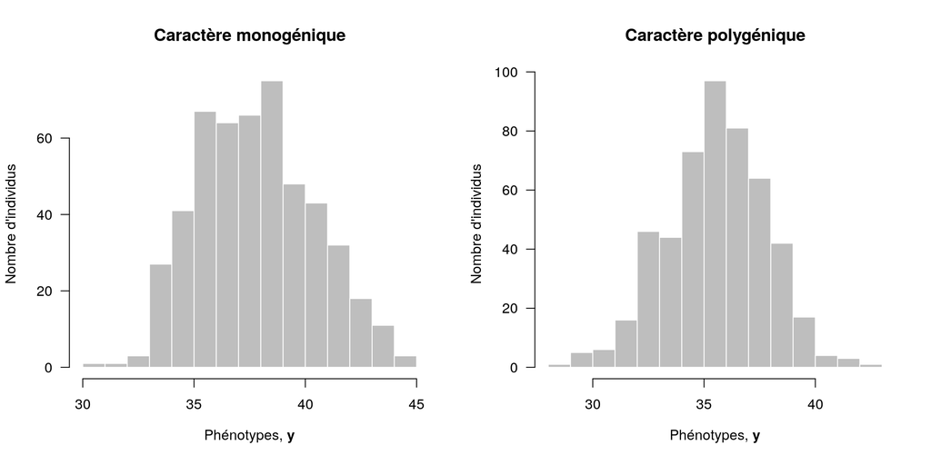

```r
par(mfrow = c(1, 2))
hist(y.mono, breaks="FD", las=1, col="grey", border="white",
     main="Caractère monogénique", ylab="Nombre d'individus",
     xlab=expression(paste("Phénotypes, ", bold(y))))
hist(y.poly, breaks="FD", las=1, col="grey", border="white",
     main="Caractère polygénique", ylab="Nombre d'individus",
     xlab=expression(paste("Phénotypes, ", bold(y))))
```

## SNP à SNP (“GWAS”)

- On utilise le package MM4LMM qui implémente un algorithme MM pour ajuster le modèle par ML ou ReML
- Caractère monogénique

```r
out.mmest <- MMEst(Y=y.mono[,1], X=X,
                   VarList=list(Additive=A.mark, Error=diag(N)))
out.anovatest <- AnovaTest(out.mmest, Type="TypeI")
res.mono.gwas <- sapply(out.anovatest, function(x){x["Xeffect", "pval"]})
```

- Caractère polygénique

```r
out.mmest <- MMEst(Y=y.poly[,1], X=X,
                   VarList=list(Additive=A.mark, Error=diag(N)))
out.anovatest <- AnovaTest(out.mmest, Type="TypeI")
res.poly.gwas <- sapply(out.anovatest, function(x){x["Xeffect", "pval"]})
```

## Tous les SNPs conjointement (“ridge”)

- On utilise le package [rrBLUP](http://cran.r-project.org/web/packages/rrBLUP/index.html)
- Caractère monogénique

```r
res.mono.ridge <- mixed.solve(y=y.mono, Z=X)
```

- Caractère polygénique

```r
res.poly.ridge <- mixed.solve(y=y.poly, Z=X)
```

## Evaluer les résultats

## Manhattan plot

- La manière habituelle de regarder les résultats des tests du modèle d’inférence SNP à SNP (GWAS) est de tracer un *Manhattan plot*
- Comme les données sont simulées, nous connaissons le SNP \(p\) avec l’effet \(\beta_p\) le plus grand, il sera indiqué d’un point rouge dans les graphiques ci-après
- Caractère monogénique

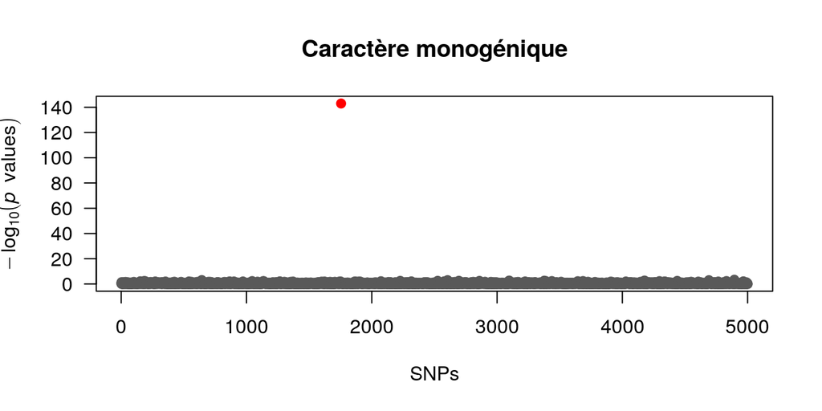

```r
plot(x=1:P, y=-log10(res.mono.gwas),
     main="Caractère monogénique", las=1, type="n",
     xlab="SNPs", ylab=expression(-log[10](italic(p)~values)))
idx <- which(names(res.mono.gwas) == snp.qtl)
points(x=which(names(res.mono.gwas) != snp.qtl),
       y=-log10(res.mono.gwas[-idx]), col="grey35", pch=19)
points(x=idx, y=-log10(res.mono.gwas[idx]), col="red", pch=19)
```

- Caractère polygénique

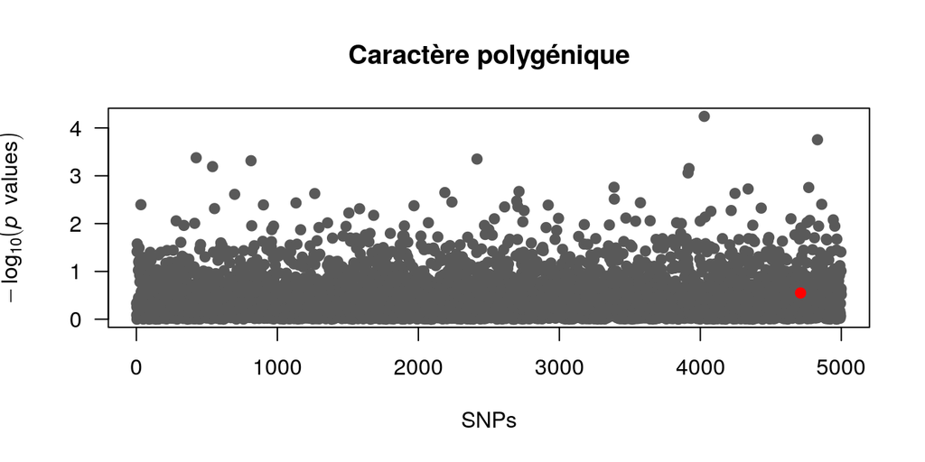

```r
plot(x=1:P, y=-log10(res.poly.gwas),
     main="Caractère polygénique", las=1, type="n",
     xlab="SNPs", ylab=expression(-log[10](italic(p)~values)))
idx <- which(names(res.poly.gwas) == names(which.max(beta.poly)))
points(x=which(names(res.poly.gwas) != names(which.max(beta.poly))),
       y=-log10(res.poly.gwas[-idx]), col="grey35", pch=19)
points(x=idx, y=-log10(res.poly.gwas[idx]), col="red", pch=19)
```

- Le modèle d’inférence SNP à SNP parvient bien à détecter le **SNP causal** dans le cas du **caractère monogénique**
- C’est beaucoup moins clair dans le cas du **caractère polygénique** : aucun SNP ne ressort vraiment et celui avec le plus grand \(\beta\) n’a pas le plus grand \(\hat{\beta}\)…

## Composantes de la variances et coefficients

```r
c(mu, res.poly.ridge$beta)
```

```
## [1] 36.0 35.4
```

```r
c(sigma.epsilon2, res.poly.ridge$Ve)
```

```
## [1] 3.00 1.93
```

```r
c(sigma.beta2.poly, res.poly.ridge$Vu)
```

```
## [1] 0.00100 0.00144
```

- Les effets aux marqueurs sont relativement mal estimés individuellement (ceci étant dû au rétrécissement opéré par la pénalité \(\lambda\))

```r
(c <- cor(beta.poly, res.poly.ridge$u))
```

```
## [1] 0.193
```

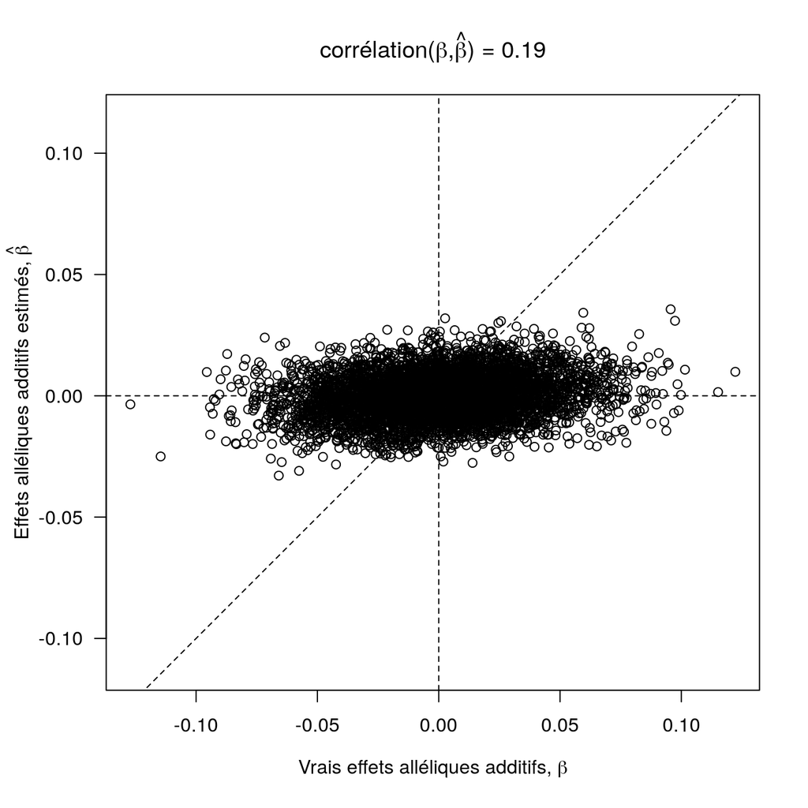

```r
par(mar=c(5, 4.5, 4, 2) + 0.1)
plot(beta.poly, res.poly.ridge$u, las=1, asp=1,
     xlab=expression(paste("Vrais effets alléliques additifs, ", bold(beta))),
     ylab=expression(paste("Effets alléliques additifs estimés, ",
                           hat(beta))),
     main=bquote(paste("corrélation(", bold(beta), ",", hat(bold(beta)), ") = ",
                       .(format(c, digits=2)))))
abline(v=0, lty=2); abline(h=0, lty=2); abline(a=0, b=1, lty=2)
```

- Par contre, les valeurs génotypiques additives, elles, sont bien mieux prédites

```r
(c <- cor(X %*% beta.poly, X %*% res.poly.ridge$u))
```

```
##       [,1]
## [1,] 0.659
```

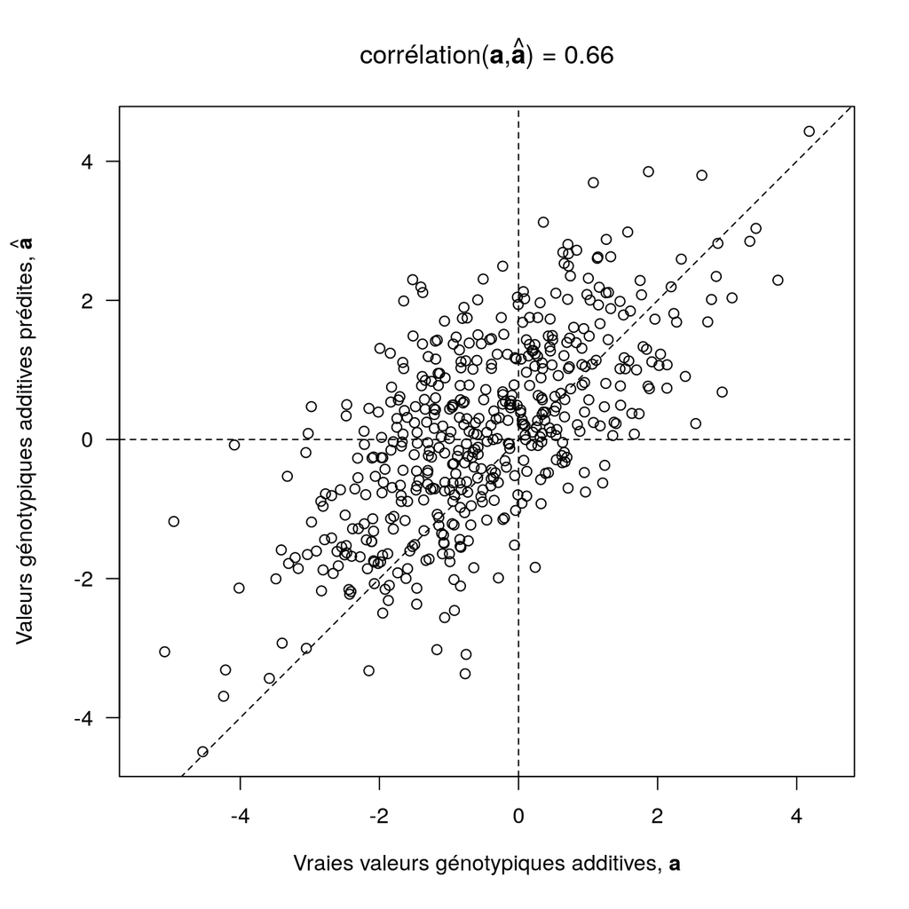

```r
par(mar=c(5, 4.5, 4, 2) + 0.1)
plot(X %*% beta.poly, X %*% res.poly.ridge$u, las=1, asp=1,
     xlab=expression(paste("Vraies valeurs génotypiques additives, ", bold(a))),
     ylab=expression(paste("Valeurs génotypiques additives prédites, ",
                           hat(bold(a)))),
     main=bquote(paste("corrélation(", bold(a), ",", hat(bold(a)), ") = ",
                       .(format(c, digits=2)))))
abline(v=0, lty=2); abline(h=0, lty=2); abline(a=0, b=1, lty=2)
```

## Bilan

- Pour les caractères **polygéniques**, le modèle d’inférence SNP à SNP (GWAS) n’est pas efficace car les effets alléliques, pris individuellement, sont trop faibles
- En estimant tous les effets conjointement avec le modèle “ridge”, même si chacun d’eux est biaisé, leur somme, elle, est estimée bien plus précisément
- On parle d’**effets alléliques “estimés”** et de **valeurs génotypiques “prédites”**, même si les deux sont des effets aléatoires dans les modèles mixtes
- L’une des raisons vient du fait que dans le modèle \(\boldsymbol{y} = \boldsymbol{1} \mu + \boldsymbol{a} + \boldsymbol{\epsilon}\), les inconnues \(\boldsymbol{a}\) sont les *breeding values* et les résultats \(\boldsymbol{\hat{a}}\) sont les *BLUPs* des *breeding values*
- C’est la raison pour laquelle on parle de **prédiction génomique**, qui mène ensuite tout naturellement à la **sélection génomique**

## Autres points importants

## Eviter le sur-ajustement

- Il est important de réaliser que les estimations des effets alléliques ont le risque d’être sur-ajustées aux individus particuliers pour lesquels on dispose de génotypes et phénotypes
- Un **sur-ajustement** a pour conséquence de mal généraliser les estimations du jeu d’entraînement pour effectuer des prédictions sur différents jeux de test
- Pour éviter cela, il est courant d’estimer les paramètres du modèle par **validation croisée**

## La validation croisée

- La variante fréquemment utilisée de cette procédure consiste à répartir aléatoirement les individus en \(k\) sous-ensembles (“folds”) de taille égale
- Pour chaque sous-ensemble \(k\), les \(k-1\) autres sont utilisés pour estimer les paramètres
- Au final, pour chaque marqueur, on dispose de \(k\) estimations de son effet allélique et on peut alors en faire la moyenne pour prédire de nouveaux individus non-phénotypés
- La validation croisée peut-être aussi utilisée pour :
  - **Sélectionner** le meilleur modèle sur le jeu d’entraînement (modèle monogénique *vs.* polygénique *vs.* … voir ci-après)
  - Estimer une **précision** de prédiction
- Chaque individu est en fait prédit une fois (lorsqu’il ne se trouve pas dans le set d’apprentissage), on peut donc calculer à partir des phénotypes observés et prédits une **erreur quadratique moyenne de validation-croisée**
- Concernant la **précision** de prédiction, on utilise plutôt la **corrélation** (coefficient de Pearson) entre les valeurs génotypiques additives prédites (\(\hat{\boldsymbol{a}}_k\)) et les phénotypes corrigés pour les facteurs environnementaux (\(\boldsymbol{y}_k\))
- En anglais on parle d’**accuracy** (et de *reliability* pour le carré de la corrélation)
- Il est recommandé de regarder également les estimations des moyenne globale et pente de la régression linéaire simple \(\boldsymbol{y}_k = a + b \, \boldsymbol{\hat{a}}_k\)
- Pour faire de la validation croisée sous R on peut utiliser le package [cvTools](https://cran.r-project.org/web/packages/cvTools/index.html)
- Mais il requiert une méthode `predict`, qui n’est pas fournie par [rrBLUP](https://cran.r-project.org/web/packages/rrBLUP/index.html)
- Il faut donc d’abord encapsuler la fonction `mixed.solve` dans une autre fonction pour qu’elle renvoie un objet de classe `"rr"`, puis ajouter la méthode `predict` à cette classe :

```r
rr <- function(y, Z, K=NULL, X=NULL, method="REML"){
  stopifnot(is.matrix(Z))
  out <- mixed.solve(y=y, Z=Z, K=K, X=X, method=method)
  return(structure(out, class="rr"))
}
predict.rr <- function(object, newZ){
  stopifnot(is.matrix(newZ))
  out <- as.vector(newZ %*% object$u)
  if(! is.null(rownames(newZ)))
    names(out) <- rownames(newZ)
  return(out)
}
```

- Une fois que c’est fait, on peut réaliser la validation croisée

```r
if(requireNamespace("cvTools", quietly=TRUE)){
  folds <- cvTools::cvFolds(n=nrow(X), K=5, R=10)
  callRR <- call("rr", y=y.poly, Z=X)
  system.time(
      out.cv <- cvTools::cvTool(call=callRR, x=X, y=y.poly, names=c("Z", "y"),
                                cost=cor, folds=folds))
}
```

- Cf. [“Exemple de simulation pour explorer la prédiction génomique”](https://github.com/timflutre/atelier-prediction-genomique/blob/master/ex_simul_pred-gen.pdf) pour plus de détails

## Intermédiaires d’architecture génétique additive

- On a vu 2 extrêmes d’architecture génétique : monogénique *vs.* polygénique
- Mais avec de “vraies” données on ne connaît généralement pas *a priori* l’architecture génétique des caractères d’intérêt
- Ne pourrait-on donc pas avoir un seul modèle s’adaptant à toutes les architectures ?
- C’est un problème plus compliqué, mais les modèles dits de **sélection de variables** vont dans ce sens en analysant conjointement tous les SNPs tout en testant lesquels ont des effets non-nuls
- C’est le cas par exemple du **Lasso** qui utilise une autre norme, \(L^1\), pour pénaliser la vraisemblance ou de l’**Elastic Net** qui combine les normes \(L^1\) et \(L^2\).

## Au-delà de l’architecture génétique additive

- La matrice \(A_{\text{mark}}\) est proportionnelle à \(X X^T\)
- L’apparentement génétique additif entre deux individus \(i\) et \(j\) est donc \(A_{ij} \propto \sum_p X_{ip} X^T_{pj} = \boldsymbol{x}_i^T \cdot \boldsymbol{x}_j\), appelé **produit scalaire** (*dot product*)
- D’un point de vue géométrique, ce produit scalaire quantifie la distance linéaire entre les deux individus dans l’espace euclidien des génotypes
- Mais on peut bien sûr utiliser d’autres fonctions de distance, non-linéaires cette fois. On utilise alors le terme de **noyau** (*kernel*) pour dénoter ces fonctions
- Afin de capturer la contribution des effets génétiques non-additifs, certains ont proposé d’utiliser le modèle \(\boldsymbol{y} = \boldsymbol{1} \mu + \boldsymbol{a} + \boldsymbol{\epsilon} \text{ avec } \boldsymbol{\epsilon} \sim \mathcal{N}_N(\boldsymbol{0}, \sigma^2 I) \text{ et } \boldsymbol{a} \sim \mathcal{N}_N(\boldsymbol{0}, \sigma_a^2 \, A_{\text{mark}})\)  
  avec \(A_{\text{mark}}\) calculée via un noyau défini dans un **espace de Hilbert à noyau reproduisant** (*Reproducing Kernel Hilbert Space*, RKHS)
- Ce terme compliqué peut en fait simplement correspondre un noyau gaussien tel que \(A_{ij} = \exp{\left( - (D_{ij} \, / \, \theta)^2 \right)}\) où \(D_{ij}\) est la distance euclidienne entre \(\boldsymbol{x}_i\) et \(\boldsymbol{x}_j\) normalisée dans l’intervalle \([0,1]\) et \(\theta\) est un paramètre d’échelle (qui doit être estimé par validation croisée)
- Le package [rrBLUP](https://cran.r-project.org/web/packages/rrBLUP/index.html) permet d’utiliser ce noyau

## Perspectives

## Explorer les simulations possibles

- Voici quelques exemples de questions que vous pouvez vous poser:
  - quel est l’impact de la fréquence allélique sur l’inférence des paramètres et la précision de la prédiction ?
  - quel est l’impact de la taille du jeu d’entraînement sur l’inférence et la prédiction ?
  - quel est l’impact de l’apparentement entre individus du jeu d’entraînement et individus du jeu de test ?

## Analyser de vrais jeux de données disponibles

- Comme l’a fait justement remarquer Zamir ([plos biology 2013](http://dx.doi.org/10.1371/journal.pbio.1001595), [science 2014](http://dx.doi.org/10.1126/science.1258941)), il est difficile de trouver des jeux de données avec phénotypes en libre accès.
- Cependant, en voici quelques uns:
  - [crossa *et al* (genetics, 2010)](http://dx.doi.org/10.1534/genetics.110.118521): blé (599 lignées, 4 conditions, rendement en grains, pédigrée, 1279 marqueurs dart) et maïs (300 lignées, 1148 marqueurs snp, 3 caractères, deux conditions)
  - [resende *et al* (genetics, 2012)](http://www.ncbi.nlm.nih.gov/pmc/articles/pmc3316659/): pin (951 individus de 61 familles, pédigrée, 4853 marqueurs snp, phénotypes dérégréssés)
  - [cleveland *et al* (g3, 2012)](http://dx.doi.org/10.1534/g3.111.001453): porc (3534 animaux, pédigrée, 5 caractères, 53000 marqueurs snp)

## Références

- Lynch, M., and B. Walsh (1998). Genetics and analysis of quantitative traits. Sinauer Associates, 1998.
- Barton, N. H. and P. D. Keightley (2002, January). Understanding quantitative genetic variation. Nature Reviews Genetics 3 (1), 11-21. [DOI](http://dx.doi.org/10.1038/nrg700)
- Weir, B. S., A. D. Anderson, and A. B. Hepler (2006, October). Genetic relatedness analysis: modern data and new challenges. Nature Reviews Genetics 7 (10), 771-780. [DOI](http://dx.doi.org/10.1038/nrg1960)
- Visscher, P. M., W. G. Hill, and N. R. Wray (2008, March). Heritability in the genomics era — concepts and misconceptions. Nature Reviews Genetics 9 (4), 255-266. [DOI](http://dx.doi.org/10.1038/nrg2322)
- Slatkin, M. (2008, June). Linkage disequilibrium — understanding the evolutionary past and mapping the medical future. Nature Reviews Genetics 9 (6), 477-485. [DOI](http://dx.doi.org/10.1038/nrg2361)
- Stephens, M. and D. J. Balding (2009, October). Bayesian statistical methods for genetic association studies. Nature Reviews Genetics 10 (10), 681-690. [DOI](http://dx.doi.org/10.1038/nrg2615)
- de los Campos, G., D. Gianola, and D. B. Allison (2010, December). Predicting genetic predisposition in humans: the promise of whole-genome markers. Nature Reviews Genetics 11 (12), 880-886. [DOI](http://dx.doi.org/10.1038/nrg2898)
- Morrell, P. L., E. S. Buckler, and J. Ross-Ibarra (2012, February). Crop genomics: advances and applications. Nature Reviews Genetics 13 (2), 85-96. [DOI](http://dx.doi.org/10.1038/nrg3097)
- Vitezica, Z., L. Varona, and A. Legarra (2013, December). On the additive and dominant variance and covariance of individuals within the genomic selection scope. Genetics 195 (4), 1223-30. [DOI](http://dx.doi.org/10.1534/genetics.113.155176)
- Howard, R., A. Carriquiry, and W. Beavis (2014, June). Parametric and nonparametric statistical methods for genomic selection of traits with additive and epistatic genetic architectures. G3 4 (6), 1027-46. [DOI](http://dx.doi.org/10.1534/g3.114.010298)
- Rabier, C.-E., Barre, P., Asp, T., Charmet, G., Mangin, B. (2016, June). On the accuracy of genomic selection. PLoS ONE 11 (6): e0156086. [DOI](https://doi.org/10.1371/journal.pone.0156086)
- Scutari, M., Mackay, I., Balding, D. (2016, September). Using genetic distance to infer the accuracy of genomic prediction. PLoS Genetics 12 (9): e1006288. [DOI](https://doi.org/10.1371/journal.pgen.1006288)
- Huang, W., and T. F. C. Mackay (2016, November). The genetic architecture of quantitative traits cannot be inferred from variance component analysis. PLoS Genetics 12 (11): e1006421. [DOI](http://dx.doi.org/10.1371/journal.pgen.1006421)